# CENSUS 2021: Education

The [CENSUS 2021](https://census.gov.uk) in England and Wales published data about [Education](https://www.ons.gov.uk/releases/educationcensus2021inenglandandwales). The release included one publication: [Education](https://www.ons.gov.uk/peoplepopulationandcommunity/educationandchildcare/bulletins/educationenglandandwales/census2021).

## Highest level of qualification

Trafford had around 10% more resident with a Level 4 qualifications or above when compared to the mean of 15 similar authorities, Greater Manchester and England. Trafford had a lower proportion of resident with any other qualification level when compared to all comparators. Trafford had a smaller proportion of residents with no qualifications when compared to the mean of 15 similar authorities (3.4% less), Greater Manchester (6% less) and England (4.1% less).

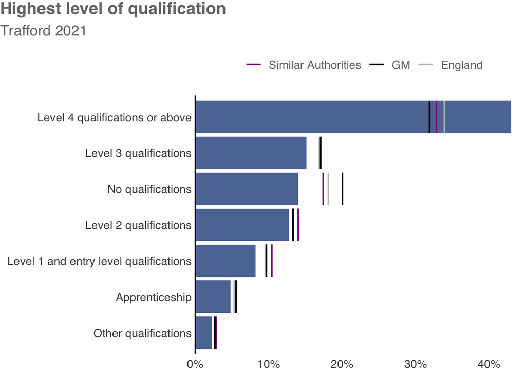

|  | Trafford | Similar Authorities | Greater Manchester | England |
| --- | --- | --- | --- | --- |
| Level 4 qualifications or above | 43% (79,961) | 32.8% | 31.88% | 33.9% |
| Level 3 qualifications | 15.1% (28,141) | 17.1% | 16.98% | 16.9% |
| No qualifications | 14% (25,990) | 17.4% | 20.02% | 18.1% |
| Level 2 qualifications | 12.7% (23,608) | 14% | 13.29% | 13.3% |
| Level 1 and entry level qualifications | 8.2% (15,309) | 10.4% | 9.64% | 9.7% |
| Apprenticeship | 4.8% ( 8,931) | 5.5% | 5.57% | 5.3% |
| Other qualifications | 2.3% ( 4,211) | 2.8% | 2.63% | 2.8% |

Contains OS data ©; Crown copyright and database right 2022  
Source: Census 2021 | @traffordDataLab

The proportion of resident with no qualifications had decreased in Trafford from 18.6% in 2011 to 14% in 2021. All MSOAs in Trafford had decreased the proportion of residents with no qualifications from 2011 to 2021.

[interactive chart not shown]

The proportion of resident with a Level 4 qualifications or above had increased in Trafford from 33.8% in 2011 to 43% in 2021. All MSOAs in Trafford had increased the proportion of residents with a Level 4 qualifications or above from 2011 to 2021.

[interactive chart not shown]

## Schoolchildren and full-time students

According to the Census 2021, 21.4% of Trafford residents aged 5 years or more were schoolchildren or full-time students, which is slightly higher than the mean of 15 similar authorities and also than England, but slightly lower than the student proportion in Greater Manchester.

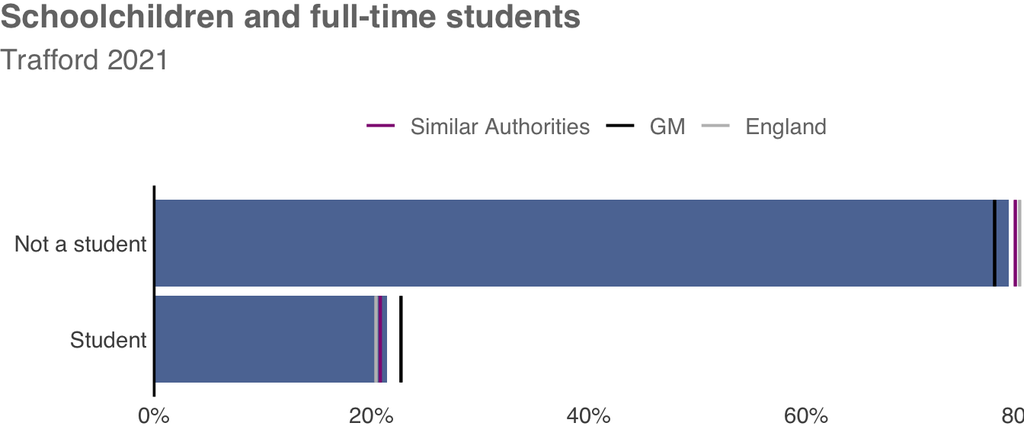

|  | Trafford | Similar Authorities | Greater Manchester | England |
| --- | --- | --- | --- | --- |
| Not a student | 78.6% (174,165) | 79.2% | 77.3% | 79.6% |
| Student | 21.4% ( 47,421) | 20.8% | 22.7% | 20.4% |

% of residents aged 5 years and over  
Source: Census 2021 | @traffordDataLab

Old Trafford MSOA have a larger number of schoolchildren and full-time students than the rest of the MSOAs in Trafford 2021. Old Trafford MSOA also have a larger proportion of students than the rest of the MSOAs.

[interactive chart not shown]